# Mari’s Work

## Table 1: Type A Model Coefficients

### Writing Score Model

| Covariate | Coefficient |
| --- | --- |
| (Intercept) | 67.7019116 |
| gendermale | -9.6034239 |
| ethnic_groupgroup B | 2.6650499 |
| ethnic_groupgroup C | 4.6637096 |
| ethnic_groupgroup D | 6.8989050 |
| ethnic_groupgroup E | 12.9775727 |
| parent_educbachelor’s degree | 3.7844797 |
| parent_educhigh school | -6.7840560 |
| parent_educmaster’s degree | 5.1368571 |
| parent_educsome college | -1.6159435 |
| parent_educsome high school | -6.5646825 |
| lunch_typestandard | 1.0114546 |
| test_prepnone | -8.8134374 |
| parent_marital_statusmarried | 7.4101213 |
| parent_marital_statussingle | -3.9987942 |
| parent_marital_statuswidowed | 12.3877539 |
| practice_sportregularly | -3.4486233 |
| practice_sportsometimes | -5.2585836 |
| is_first_childyes | 6.1752314 |
| transport_meansschool_bus | 5.9968222 |
| wkly_study_hours> 10 | -13.4167734 |
| wkly_study_hours10-May | -1.3229981 |
| ethnic_groupgroup B:transport_meansschool_bus | -6.3830679 |
| ethnic_groupgroup C:transport_meansschool_bus | -7.4764593 |
| ethnic_groupgroup D:transport_meansschool_bus | -2.4486808 |
| ethnic_groupgroup E:transport_meansschool_bus | -10.3029259 |
| lunch_typestandard:practice_sportregularly | 6.1613706 |
| lunch_typestandard:practice_sportsometimes | 10.0219483 |
| lunch_typestandard:wkly_study_hours> 10 | 5.9187672 |
| lunch_typestandard:wkly_study_hours10-May | -0.0747530 |
| parent_marital_statusmarried:is_first_childyes | -7.6254632 |
| parent_marital_statussingle:is_first_childyes | -0.7356701 |
| parent_marital_statuswidowed:is_first_childyes | -5.7472401 |
| parent_marital_statusmarried:wkly_study_hours> 10 | 10.2657209 |
| parent_marital_statussingle:wkly_study_hours> 10 | 18.6798500 |
| parent_marital_statuswidowed:wkly_study_hours> 10 | 5.9266827 |
| parent_marital_statusmarried:wkly_study_hours10-May | 3.3299876 |
| parent_marital_statussingle:wkly_study_hours10-May | 8.2992048 |
| parent_marital_statuswidowed:wkly_study_hours10-May | -0.2843766 |

The proper interpretation of these coefficients is as follows: Holding all other variables constant, one unit increase in [covariate] leads to [coefficient] units increase in the outcome of interest.

### Math Score Model

| Covariate | Coefficient |
| --- | --- |
| (Intercept) | 43.4922358 |
| gendermale | 5.0562224 |
| ethnic_groupgroup B | 3.1098535 |
| ethnic_groupgroup C | 4.7866745 |
| ethnic_groupgroup D | 4.4789082 |
| ethnic_groupgroup E | 19.5605426 |
| parent_educbachelor’s degree | 22.6141675 |
| parent_educhigh school | -11.9676346 |
| parent_educmaster’s degree | -1.9383911 |
| parent_educsome college | 0.8824346 |
| parent_educsome high school | 1.6695670 |
| lunch_typestandard | 5.7052422 |
| test_prepnone | -1.1067500 |
| parent_marital_statusmarried | 9.7201559 |
| parent_marital_statussingle | 3.7791454 |
| parent_marital_statuswidowed | 29.2537745 |
| practice_sportregularly | -4.2708885 |
| practice_sportsometimes | -6.0415129 |
| is_first_childyes | 12.5726213 |
| transport_meansschool_bus | 5.2495442 |
| wkly_study_hours> 10 | -4.8803371 |
| wkly_study_hours10-May | 4.6584310 |
| ethnic_groupgroup B:transport_meansschool_bus | -4.3676804 |
| ethnic_groupgroup C:transport_meansschool_bus | -7.7457168 |
| ethnic_groupgroup D:transport_meansschool_bus | -0.9133233 |
| ethnic_groupgroup E:transport_meansschool_bus | -10.3518240 |
| parent_educbachelor’s degree:parent_marital_statusmarried | -18.4745055 |
| parent_educhigh school:parent_marital_statusmarried | 0.7418296 |
| parent_educmaster’s degree:parent_marital_statusmarried | 1.1992797 |
| parent_educsome college:parent_marital_statusmarried | -7.4231719 |
| parent_educsome high school:parent_marital_statusmarried | -8.2282777 |
| parent_educbachelor’s degree:parent_marital_statussingle | -23.6303814 |
| parent_educhigh school:parent_marital_statussingle | 1.7140663 |
| parent_educmaster’s degree:parent_marital_statussingle | -0.6344053 |
| parent_educsome college:parent_marital_statussingle | -11.5880740 |
| parent_educsome high school:parent_marital_statussingle | -11.5407169 |
| parent_educbachelor’s degree:parent_marital_statuswidowed | -33.5004309 |
| parent_educhigh school:parent_marital_statuswidowed | -46.5554305 |
| parent_educmaster’s degree:parent_marital_statuswidowed | -48.9590039 |
| parent_educsome college:parent_marital_statuswidowed | -15.7098935 |
| parent_educsome high school:parent_marital_statuswidowed | -19.2637612 |
| parent_educbachelor’s degree:is_first_childyes | -3.3589159 |
| parent_educhigh school:is_first_childyes | 8.9969202 |
| parent_educmaster’s degree:is_first_childyes | 4.7183498 |
| parent_educsome college:is_first_childyes | 6.6947300 |
| parent_educsome high school:is_first_childyes | 2.0435608 |
| lunch_typestandard:practice_sportregularly | 8.4202603 |
| lunch_typestandard:practice_sportsometimes | 11.3662476 |
| lunch_typestandard:transport_meansschool_bus | -3.4367789 |
| test_prepnone:is_first_childyes | -3.6884111 |
| test_prepnone:wkly_study_hours> 10 | -6.2865162 |
| test_prepnone:wkly_study_hours10-May | -0.1976361 |
| parent_marital_statusmarried:is_first_childyes | -8.7046743 |
| parent_marital_statussingle:is_first_childyes | -1.9060434 |
| parent_marital_statuswidowed:is_first_childyes | 13.7975072 |
| parent_marital_statusmarried:transport_meansschool_bus | 7.2707112 |
| parent_marital_statussingle:transport_meansschool_bus | 2.4715132 |
| parent_marital_statuswidowed:transport_meansschool_bus | -14.6084845 |
| parent_marital_statusmarried:wkly_study_hours> 10 | 11.6353641 |
| parent_marital_statussingle:wkly_study_hours> 10 | 18.6339250 |
| parent_marital_statuswidowed:wkly_study_hours> 10 | 11.9898110 |
| parent_marital_statusmarried:wkly_study_hours10-May | 2.1126896 |
| parent_marital_statussingle:wkly_study_hours10-May | 5.6964972 |
| parent_marital_statuswidowed:wkly_study_hours10-May | 11.8849084 |
| is_first_childyes:transport_meansschool_bus | -4.4000451 |
| is_first_childyes:wkly_study_hours> 10 | -0.6479428 |
| is_first_childyes:wkly_study_hours10-May | -5.6645835 |

The proper interpretation of these coefficients is as follows: Holding all other variables constant, one unit increase in [covariate] leads to [coefficient] units increase in the outcome of interest.

### Reading Score

| Covariate | Coefficient |
| --- | --- |
| (Intercept) | 64.0126041 |
| gendermale | -7.9731396 |
| ethnic_groupgroup B | 4.0052327 |
| ethnic_groupgroup C | 4.5816846 |
| ethnic_groupgroup D | 4.6170265 |
| ethnic_groupgroup E | 13.9573551 |
| parent_educbachelor’s degree | 3.3736355 |
| parent_educhigh school | -5.9246720 |
| parent_educmaster’s degree | 3.4396925 |
| parent_educsome college | -2.3224110 |
| parent_educsome high school | -5.3231611 |
| lunch_typestandard | 2.0599169 |
| test_prepnone | -6.2162101 |
| parent_marital_statusmarried | 10.2556824 |
| parent_marital_statussingle | -0.8882264 |
| parent_marital_statuswidowed | 17.2457132 |
| practice_sportregularly | -4.4244752 |
| practice_sportsometimes | -5.4217479 |
| is_first_childyes | 8.8087009 |
| transport_meansschool_bus | 7.1539912 |
| wkly_study_hours> 10 | -15.1279594 |
| wkly_study_hours10-May | 1.2357744 |
| ethnic_groupgroup B:transport_meansschool_bus | -8.5078012 |
| ethnic_groupgroup C:transport_meansschool_bus | -8.7787161 |
| ethnic_groupgroup D:transport_meansschool_bus | -2.4914229 |
| ethnic_groupgroup E:transport_meansschool_bus | -12.1513487 |
| lunch_typestandard:practice_sportregularly | 4.3133911 |
| lunch_typestandard:practice_sportsometimes | 9.0693350 |
| lunch_typestandard:wkly_study_hours> 10 | 6.1826905 |
| lunch_typestandard:wkly_study_hours10-May | -1.3340808 |
| parent_marital_statusmarried:is_first_childyes | -10.3012497 |
| parent_marital_statussingle:is_first_childyes | -2.7153494 |
| parent_marital_statuswidowed:is_first_childyes | -11.5350578 |
| parent_marital_statusmarried:wkly_study_hours> 10 | 11.8332834 |
| parent_marital_statussingle:wkly_study_hours> 10 | 20.4572041 |
| parent_marital_statuswidowed:wkly_study_hours> 10 | 5.7848280 |
| parent_marital_statusmarried:wkly_study_hours10-May | 1.7017544 |
| parent_marital_statussingle:wkly_study_hours10-May | 5.0454905 |
| parent_marital_statuswidowed:wkly_study_hours10-May | -3.6043323 |

The proper interpretation of these coefficients is as follows: Holding all other variables constant, one unit increase in [covariate] leads to [coefficient] units increase in the outcome of interest.

### Table 2: Multiple and Adjusted $$R^2$$ for all models

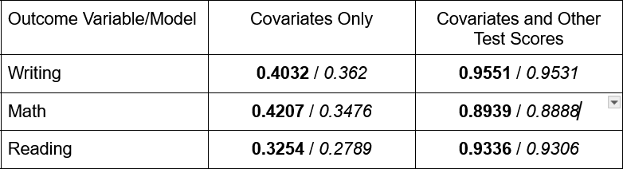

Multiple
$$R^2$$
is bold, adjusted
$$R^2$$
is italicized.

## Table 3: Type B Model Coefficients

### Writing Score with Other Scores as Predictors

| Covariate | Coefficient |
| --- | --- |
| (Intercept) | 1.8887616 |
| gendermale | -6.0578706 |
| ethnic_groupgroup B | -0.4101061 |
| ethnic_groupgroup C | 0.5802956 |
| ethnic_groupgroup D | 2.1894542 |
| ethnic_groupgroup E | -1.0099243 |
| parent_educbachelor’s degree | 0.9536092 |
| parent_educhigh school | -1.4646427 |
| parent_educmaster’s degree | 2.4499005 |
| parent_educsome college | 0.1507372 |
| parent_educsome high school | -1.6961199 |
| lunch_typestandard | 0.2287684 |
| test_prepnone | -3.3650862 |
| parent_marital_statusmarried | 0.0939641 |
| parent_marital_statussingle | 0.2058865 |
| parent_marital_statuswidowed | 0.9320512 |
| practice_sportregularly | 1.5653436 |
| practice_sportsometimes | 0.8226377 |
| is_first_childyes | -0.2082400 |
| transport_meansschool_bus | -1.4653048 |
| wkly_study_hours> 10 | -0.3405180 |
| wkly_study_hours10-May | 0.0123796 |
| reading_score | 0.7290976 |
| math_score | 0.4190312 |
| transport_meansschool_bus:reading_score | 0.0230636 |
| reading_score:math_score | -0.0016988 |

The proper interpretation of these coefficients is as follows: Holding all other variables constant, one unit increase in [covariate] leads to [coefficient] units increase in the outcome of interest.

## Math Score with Other Scores as Predictors

| Covariate | Coefficient |
| --- | --- |
| (Intercept) | -9.4478352 |
| gendermale | 13.9310258 |
| ethnic_groupgroup B | 0.9575902 |
| ethnic_groupgroup C | -0.1500629 |
| ethnic_groupgroup D | -0.8904819 |
| ethnic_groupgroup E | 5.2158484 |
| parent_educbachelor’s degree | -1.3248714 |
| parent_educhigh school | 0.6757209 |
| parent_educmaster’s degree | -3.2424452 |
| parent_educsome college | 0.1386980 |
| parent_educsome high school | 0.7638305 |
| lunch_typestandard | 1.5110651 |
| test_prepnone | 4.1051371 |
| parent_marital_statusmarried | 0.2781327 |
| parent_marital_statussingle | -0.1017812 |
| parent_marital_statuswidowed | 1.1956141 |
| practice_sportregularly | 0.4596391 |
| practice_sportsometimes | 0.0950948 |
| is_first_childyes | -1.5827564 |
| transport_meansschool_bus | 0.0626096 |
| wkly_study_hours> 10 | -4.9391993 |
| wkly_study_hours10-May | -2.9390114 |
| reading_score | 0.1675506 |
| writing_score | 0.7674974 |
| lunch_typestandard:is_first_childyes | 2.5464054 |
| test_prepnone:transport_meansschool_bus | -1.3404825 |
| wkly_study_hours> 10:reading_score | 0.1000068 |
| wkly_study_hours10-May:reading_score | 0.0554654 |

The proper interpretation of these coefficients is as follows: Holding all other variables constant, one unit increase in [covariate] leads to [coefficient] units increase in the outcome of interest.

## Reading Score with Other Scores as Predictors

| Covariate | Coefficient |
| --- | --- |
| (Intercept) | 2.2512938 |
| gendermale | -0.1377977 |
| ethnic_groupgroup B | -0.1399523 |
| ethnic_groupgroup C | -0.8456703 |
| ethnic_groupgroup D | -2.1742851 |
| ethnic_groupgroup E | -0.8495220 |
| parent_educbachelor’s degree | -0.3194345 |
| parent_educhigh school | 0.9325487 |
| parent_educmaster’s degree | -0.9991043 |
| parent_educsome college | -0.5342048 |
| parent_educsome high school | 1.3485517 |
| lunch_typestandard | -1.2290996 |
| test_prepnone | 1.9926513 |
| parent_marital_statusmarried | 0.0740501 |
| parent_marital_statussingle | -0.1264861 |
| parent_marital_statuswidowed | -1.4360788 |
| practice_sportregularly | -2.0714620 |
| practice_sportsometimes | -0.7828685 |
| is_first_childyes | -0.6219640 |
| transport_meansschool_bus | 1.1396578 |
| wkly_study_hours> 10 | -0.3184942 |
| wkly_study_hours10-May | -0.1845646 |
| writing_score | 0.8931576 |
| math_score | 0.1209110 |
| is_first_childyes:transport_meansschool_bus | 1.5524335 |
| transport_meansschool_bus:writing_score | -0.0297898 |

The proper interpretation of these coefficients is as follows: Holding all other variables constant, one unit increase in [covariate] leads to [coefficient] units increase in the outcome of interest.

## Explore Diagnostics for These Models

### Figure 1: Diagnostic plots for the Writing Type A Model

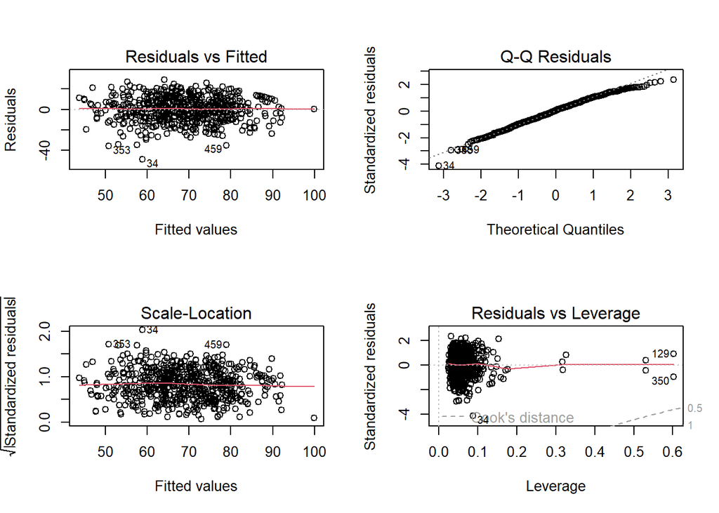

### Figure 2: Diagnostic plots for the Math Type A Model

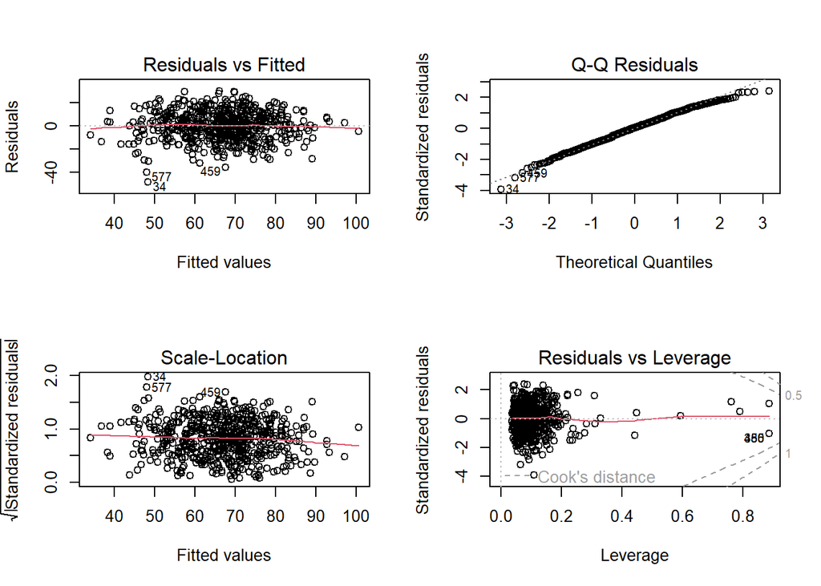

### Figure 3: Diagnostic plots for the Reading Type A Model

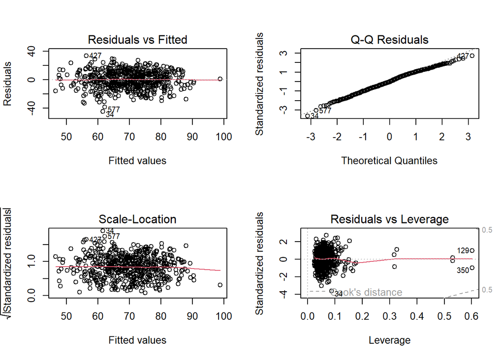

### Figure 4: Diagnostic plots for the Writing Type B Model

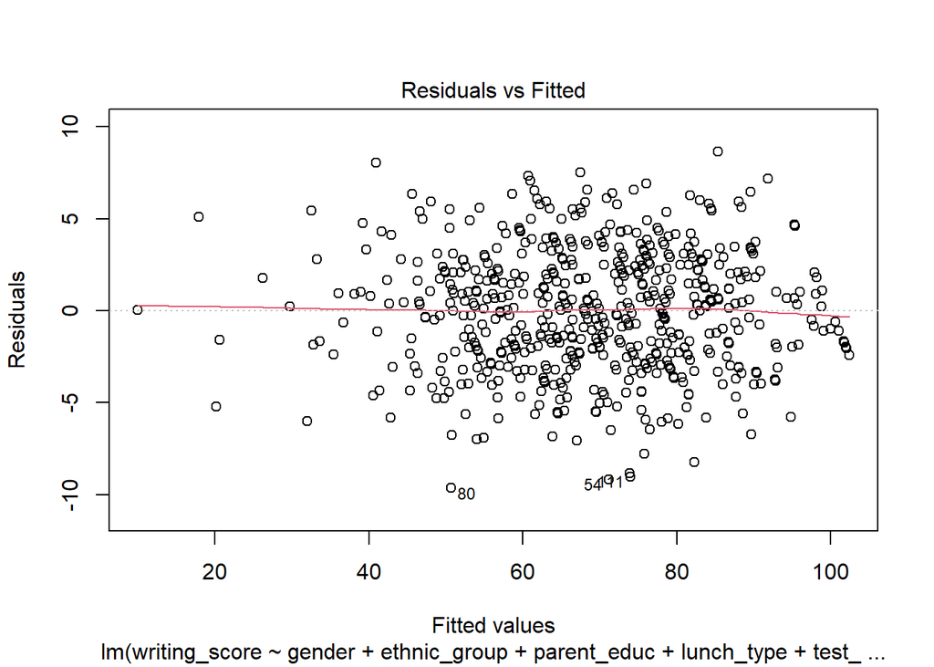

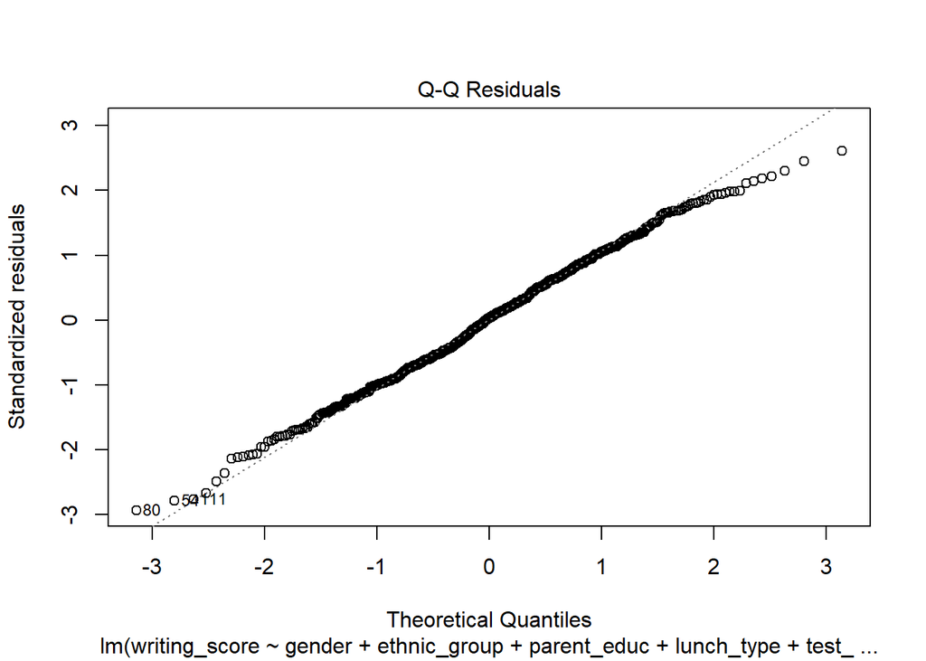

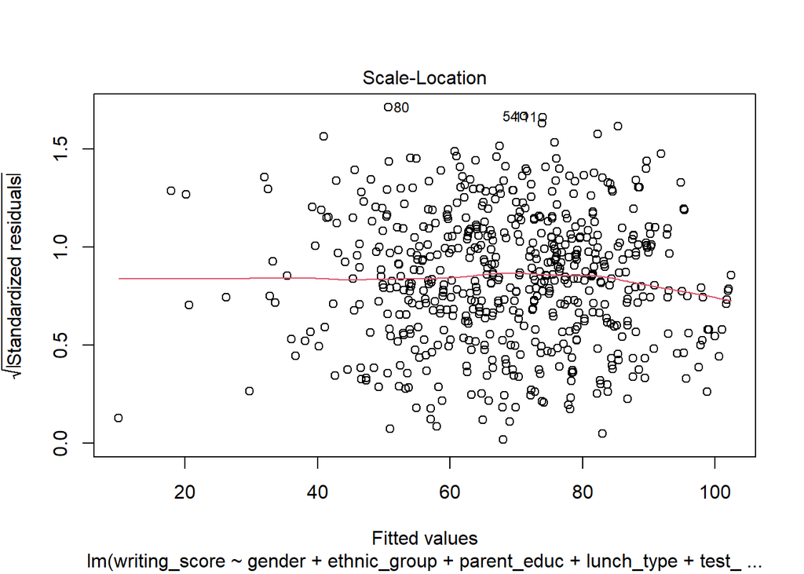

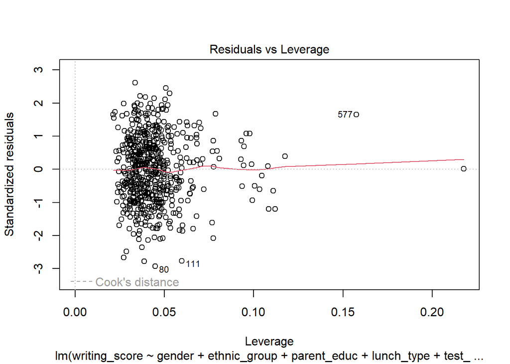

### Figure 5: Diagnostic plots for the Math Type B Model

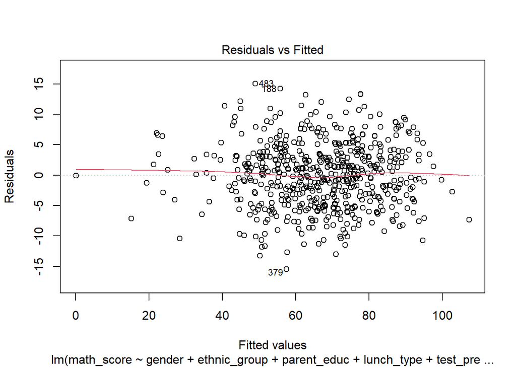

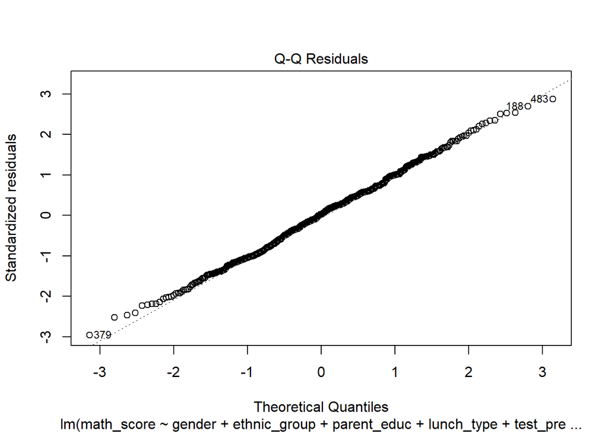

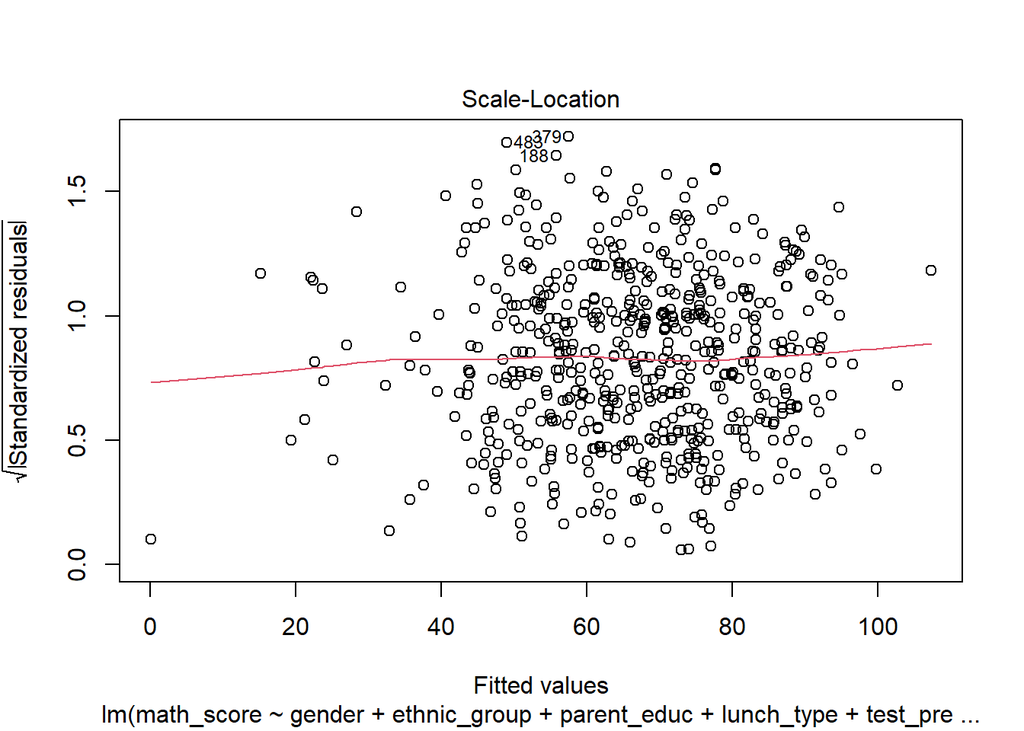

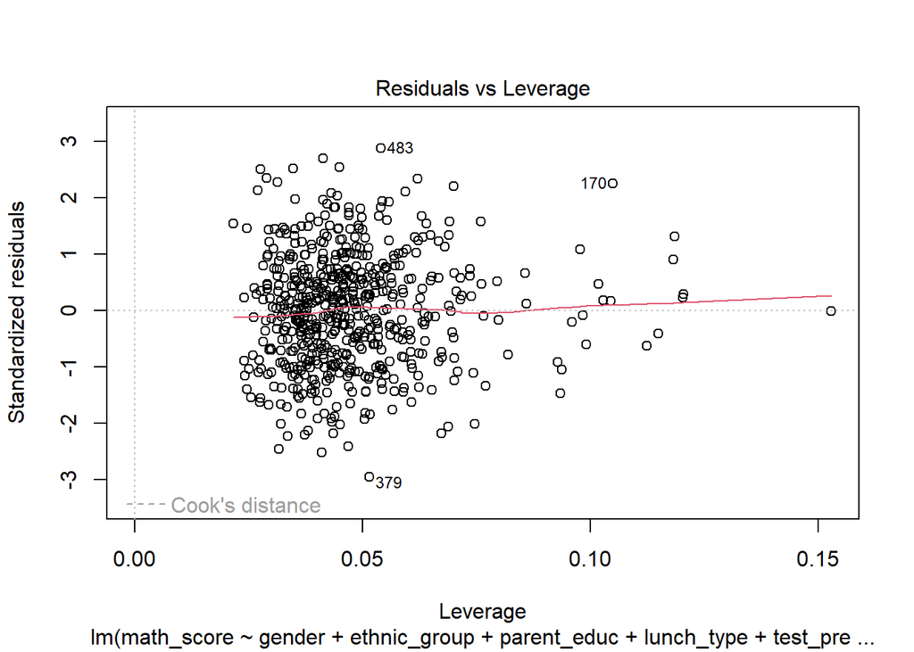

### Figure 6: Diagnostic plots for the Reading Type B Model

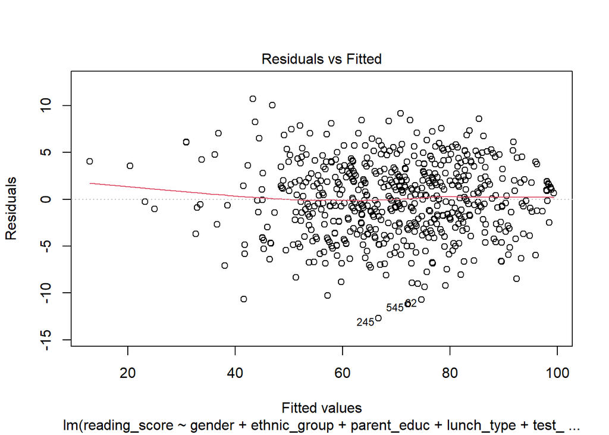

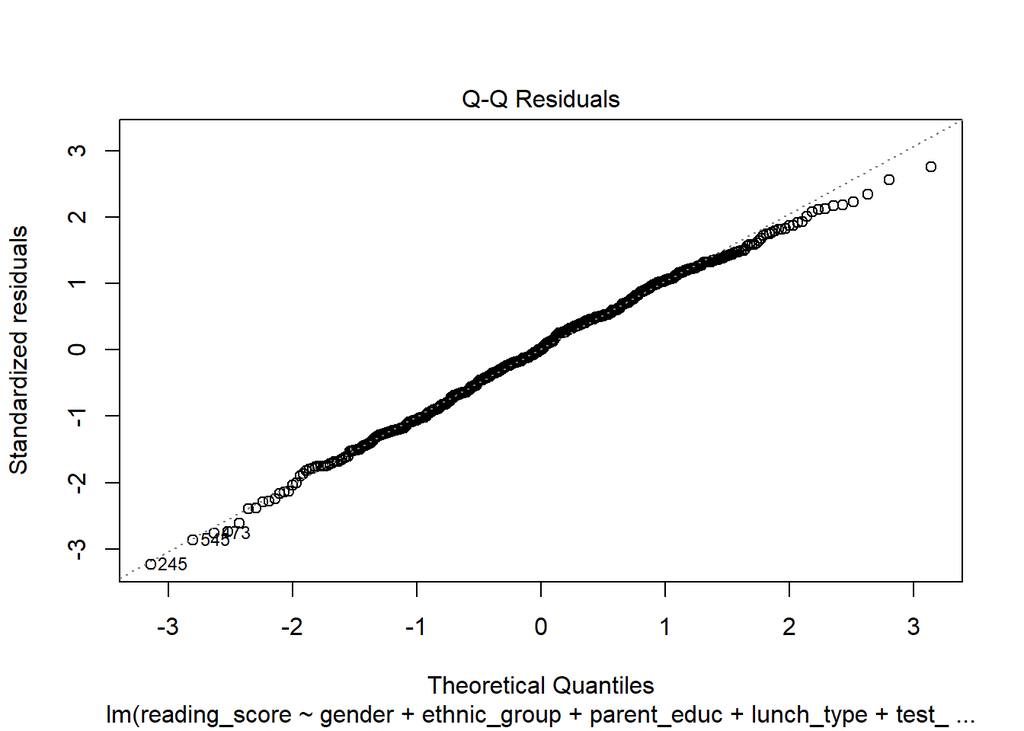

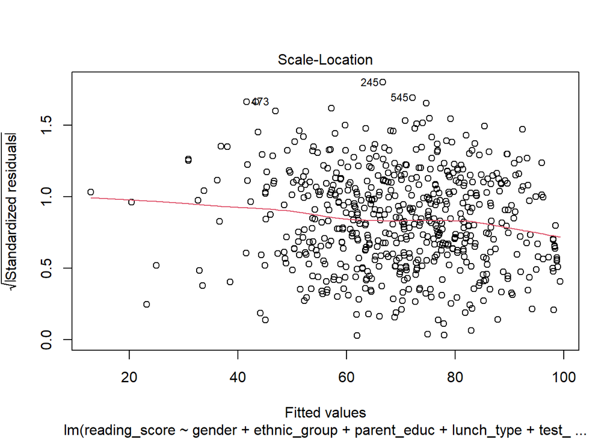

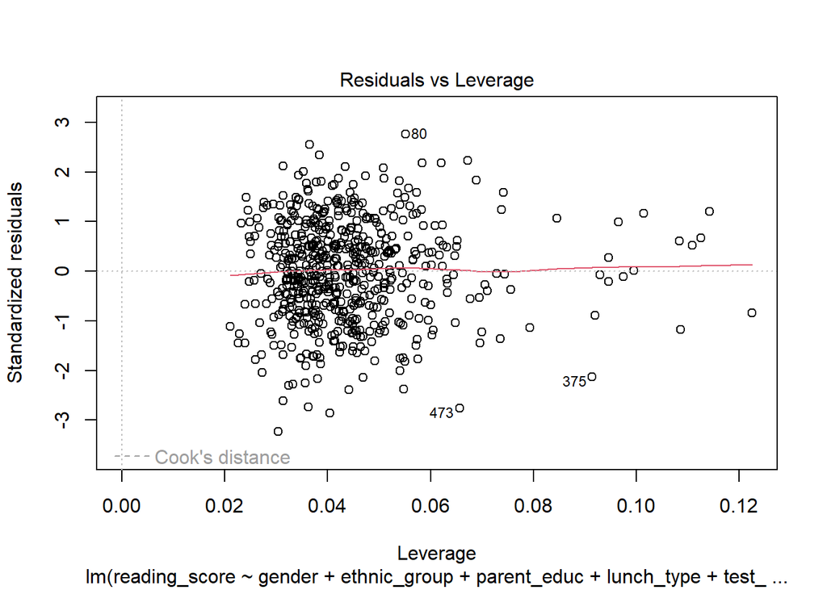